John Baskerville

# Artificial Neural Network Project

# Objective

League of Legends is a competitive online battle arena where two teams of 5 players and their unique characters face off on a map. The objective of each match is to infiltrate the enemy team base and destroy its nexus. Each match lasts around 30 minutes and the depth of gameplay requires cooperation, management of resources, and strategy in order to win a match. The objective of this project is to use a ranked game dataset and its features to categorize the results of a match as either a win or a loss for either the red or blue team.

#### Source URL

Dataset URL: https://www.kaggle.com/bobbyscience/league-of-legends-diamond-ranked-games-10-min

```python
#import pandas to handle dataset in easy to use table format
import pandas as pd
#preprocessing package from sklearn will normalize data, making it easier for keras and model to learn
from sklearn import preprocessing
#train_test_split function for easy validation splits
#GridSearch will be used to select optimal parameters
from sklearn.model_selection import train_test_split, GridSearchCV
#import keras libraries to build model and manipulate layers
from keras.wrappers.scikit_learn import KerasClassifier
from keras.models import Sequential
from keras.layers import Dense, Activation, Dropout
from keras.optimizers import SGD
#import plotting libraries
from matplotlib import pyplot as plt
#use datetime to track time spent training
import datetime
#import numpy for data preprocessing and random seed setting
import numpy as np
#if needed, will transform y variable.
from keras.utils import to_categorical
#seaborn library to help visualize correlations
import seaborn as sns
```

# Input variables and Preprocessing steps

There 2 teams with 19 features each. Each row represents 1 game with collected data from the first 10 minutes. I expected some of the features to be highly correlated. Events such as takedowns of other players and completing in-game objectives all grant gold and gold is one of the most important resources to help characters progress in each match.

The column ‘blueWins’ is the dependent variable and a value of 1 represents a win for the blue team.

```python
#store raw data in 'data' variable
data = pd.read_csv("high_diamond_ranked_10min.csv")

#create scaler function that will compress data to reduce varaibilty between features
min_max_scaler = preprocessing.MinMaxScaler()

#isolate dependant variable
y = data['blueWins'] # binary data
#Y = to_categorical(Y)
#First model will use all features except dependant variable and gameID
X = data.drop(['blueWins','gameId'],axis=1)
#use min max function to transform data
X = min_max_scaler.fit_transform(X)
#use train_test_split function to separate data for validation
X_train, X_test, y_train, y_test = train_test_split(X, y, test_size=0.2, random_state=99)

#dataShrink variable is new dataset with all highly correlated features removed
# dataShrink = data.drop(['blueWins','gameId','redFirstBlood','blueTotalGold','blueGoldPerMin','redDeaths',
#                   'redKills','redTotalGold','redGoldPerMin','blueCSPerMin',
#                   'blueExperienceDiff','redCSPerMin','redGoldDiff',
#                   'blueTotalExperience','redTotalExperience','redExperienceDiff',
#                    'blueAssists','redAssists','redEliteMonsters'],axis=1)
# data1 = min_max_scaler.fit_transform(dataShrink)
#X1_train, X1_test, Y1_train, Y1_test = train_test_split(data1, Y, test_size=0.18, random_state=42)
```

# Feature Selection

There are 38 features total, so the initial heatmap looks cluttered, but there are clear and obvious features that can be easily be removed. A feature that is highly correlated to another is likely to have the same effect on the dependent variable and likely is not needed.

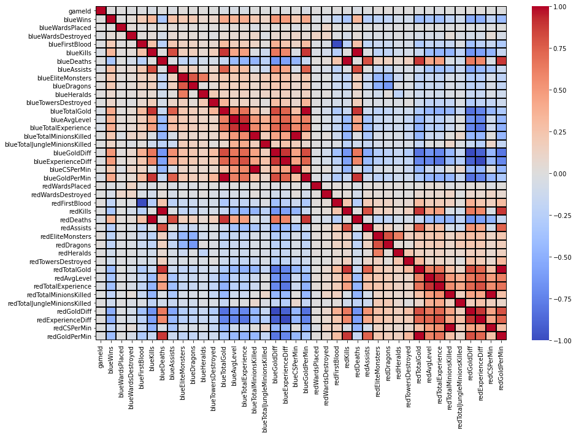

```python
#create figure for heatmap plot
plt.figure(figsize = (15,10)) # width x height
#create correlation matrix with data
corr = data.corr()
#use heatmatp function to visualize correlations
sns.heatmap(corr,cmap='coolwarm',annot=False,linecolor='black',linewidth=1)
```

# ANN model

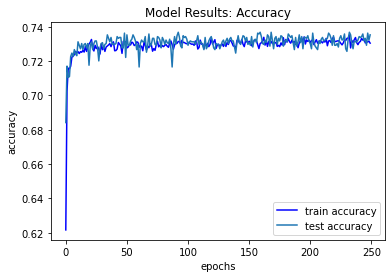

```python
seed = 100
np.random.seed(seed)

def build_model():
    model=Sequential()
    #input layer
    model.add(Dense(5,input_dim=38,activation='softmax'))
    model.add(Dense(250))
    model.add(Dense(10))
    model.add(Dense(10))
    model.add(Dense(14))
    model.add(Dense(35))
    model.add(Dense(10))
    model.add(Dense(10))
    model.add(Dense(10))
    model.add(Dense(1))
    model.add(Activation('sigmoid'))
    #optimizer = SGD(lr=.001, momentum=.5)
    #compile model with appropriate metrics
    model.compile(loss='binary_crossentropy',optimizer='adam', metrics=['binary_accuracy','acc'])
    return model

#the model will flatten before this limit
epochs = 250
#accurate and speedy batch size
batch_size = 100
#model parameterization used to help optimize parameters
model = KerasClassifier(build_fn=build_model)
#fit model
modelFit = model.fit(X_train,y_train,epochs=epochs, batch_size=batch_size,verbose=0,validation_data=(X_test,y_test))

#plot loss and accuracy of trained model.
plt.figure()
plt.plot(modelFit.history['binary_accuracy'], color='blue', label='train accuracy')
plt.plot(modelFit.history['val_binary_accuracy'], label='test accuracy')
plt.xlabel("epochs")
plt.ylabel("accuracy")
plt.legend()
plt.title("Model Results: Accuracy")
```

# Results

```python
from sklearn.metrics import confusion_matrix, accuracy_score

prediction = model.predict(X_test)
cm = confusion_matrix(y_test,prediction)
score = accuracy_score(y_test,prediction)
print("Confusion Matrix \n",cm)
print("\nModel Accuracy Score: ",score)
```

```
Confusion Matrix
 [[712 282]
 [241 741]]

Model Accuracy Score:  0.7353238866396761
```

# Final Model and Training Algorithm summary

The model converged on an accuracy pretty quickly and most training was able to be completed within 20 epochs with a batch size of 100.

```python
modelFit.model.summary()
```

```
_________________________________________________________________
Layer (type)                 Output Shape              Param #
=================================================================
dense_176 (Dense)            (None, 5)                 195
_________________________________________________________________
dense_177 (Dense)            (None, 250)               1500
_________________________________________________________________
dense_178 (Dense)            (None, 10)                2510
_________________________________________________________________
dense_179 (Dense)            (None, 10)                110
_________________________________________________________________
dense_180 (Dense)            (None, 14)                154
_________________________________________________________________
dense_181 (Dense)            (None, 35)                525
_________________________________________________________________
dense_182 (Dense)            (None, 10)                360
_________________________________________________________________
dense_183 (Dense)            (None, 10)                110
_________________________________________________________________
dense_184 (Dense)            (None, 10)                110
_________________________________________________________________
dense_185 (Dense)            (None, 1)                 11
_________________________________________________________________
activation_22 (Activation)   (None, 1)                 0
=================================================================
Total params: 5,585
Trainable params: 5,585
Non-trainable params: 0
_________________________________________________________________
```

# Metrics and justification

The metrics used in these models is binary_accuracy. The dependant variable in the data is represented by either a 0 or a 1 and the binary accuracy metric calculates how often predictions match binary labels.

# Validation methods

The intial models were validated with a reserved dataset that was split at the initial preprocess step. This was a quick way to get the first few models tested and benchmarked.The sweetspot for validation allocation rested between 15% and 25% of the dataset.

When the final models were being tested, I decided to allow the GridSearch to use crossfold validation or kfold. The comprimise between time and accuracy came down to 3,4 and 5 folds for validating the data.

# Optimization

I had to be careful not to add too many combinations of parameters to test. After narrowing in on the best activation functions to use, I was greedy with my approach and was forced to terminate a training session that was going over 7 hours. Computing limitations forced me to create optimization code that ran in the range of 0:00 - 25:00 minutes.

GridSearchCV is used to tune parameters. First, the activation function for the input and output layers were tested with 10 different combinations with the relevant activations below. This had a total run time of 0:22:35.514558 (H:mm:ss).

activations1 = ['softmax', 'softplus', 'softsign', 'sigmoid', 'hard_sigmoid']  
activations2 = ['softmax','sigmoid']

Once the optimal activations were found the next step was to find an optimal Neural Network shape. The first test included experimenting with 3 models of various shapes. I tested models with 2 and 3 layer deep networks with nodes varying in the range of 10-25. My initial strategy was to focus on a network with nodes in a similar range to the feature length (21).

The initial winner of the shape training was a model with 2 layers with 20 and 10 nodes respectivly. This winning shape was used to test model paremters even further.

Next I tried to test too many parameters and epochs. The following paremeter combinations resulted in a model that took too long to train. epochs = 100 drop = [.2,.3,.5] batch_size = [32,128,256] model = KerasClassifier(build_fn=build_model,epochs=epochs)#batch_size=batch_size) l=[(20,10,10),(20,10),(25,25,10)] This is the layer and node combination tests.

After doing using more optimization loops to find optimal batch size, dropout, momentum and learning rate.

The best accuracy is: 0.728819 using {'batch_size': 128, 'drop': 0.1, 'layers': (10, 20, 10)}

# 13. Final Discussion

There is room for improvement with this model. After spending hours trying to determing the optimal combinations of layers and nodes the final model was decided with random testing and maunal tweeking. A more systytematic approach where much much more time is spent on optimizing paremters can push the model into a higher accuracy.